# ADS Final Presentation - Team O

# Introduction to the Problem

- How to select the stock beating the market (index performance)
- How to select the stock with postive return -Does historical performance help? -Does factors in quarterly report help?

# Description of the Data

- From API of Bloomberg Terminal
- Two data sets

|  | Dates | Sectors | Stocks | PX_OFFICIAL_CLOSE | Return | PE_RATIO | PX_TO_BOOK_RATIO | PX_TO_SALES_RATIO | PX_TO_FREE_CASH_FLOW | EQY_DPS | RETURN_COM_EQY | RETURN_ON_ASSET | SALES_GROWTH | EBITDA_GROWTH | EBITDA | PROF_MARGIN | TOT_DEBT_TO_TOT_ASSET | ASSET_TURNOVER | NET_FIX_ASSET_TURN | INVENT_TURN | RETURN_ON_INV_CAPITAL | TURNOVER | Month | Year |
| --- | --- | --- | --- | --- | --- | --- | --- | --- | --- | --- | --- | --- | --- | --- | --- | --- | --- | --- | --- | --- | --- | --- | --- | --- |
| 1 | 2014-11-07 | Energy | XOM US Equity | 96.59 |  | 12.1497 | 2.2652 | 1.0799 | 27.0166 | 0.69 | 19.6094 | 9.7954 | -4.7966 | -4.1936 | 9636 | 8.4337 | 6.1894 | 1.1017 | 1.567 | 19.2301 | 12.0724 | 1279145000 | November | 2014 |
| 2 | 2014-11-10 | Energy | XOM US Equity | 96.28 | -0.00320944197121853 | 12.1107 | 2.2579 | 1.0764 | 26.9299 | 0.69 | 19.6094 | 9.7954 | -4.7966 | -4.1936 | 9636 | 8.4337 | 6.1894 | 1.1017 | 1.567 | 19.2301 | 12.0724 | 876702800 | November | 2014 |
| 3 | 2014-11-11 | Energy | XOM US Equity | 96.41 | 0.00135022850020761 | 12.127 | 2.2609 | 1.0779 | 26.9663 | 0.69 | 19.6094 | 9.7954 | -4.7966 | -4.1936 | 9636 | 8.4337 | 6.1894 | 1.1017 | 1.567 | 19.2301 | 12.0724 | 768618900 | November | 2014 |
| 4 | 2014-11-12 | Energy | XOM US Equity | 95.38 | -0.0106835390519656 | 11.9975 | 2.2368 | 1.0664 | 26.6782 | 0.69 | 19.6094 | 9.7954 | -4.7966 | -4.1936 | 9636 | 8.4337 | 6.1894 | 1.1017 | 1.567 | 19.2301 | 12.0724 | 1108916000 | November | 2014 |
| 5 | 2014-11-13 | Energy | XOM US Equity | 94.66 | -0.00754875235898511 | 11.9069 | 2.2199 | 1.0583 | 26.4768 | 0.69 | 19.6094 | 9.7954 | -4.7966 | -4.1936 | 9636 | 8.4337 | 6.1894 | 1.1017 | 1.567 | 19.2301 | 12.0724 | 1167975000 | November | 2014 |
| 6 | 2014-11-14 | Energy | XOM US Equity | 95.09 | 0.00454257342066344 | 11.961 | 2.23 | 1.0631 | 26.597 | 0.69 | 19.6094 | 9.7954 | -4.7966 | -4.1936 | 9636 | 8.4337 | 6.1894 | 1.1017 | 1.567 | 19.2301 | 12.0724 | 887325600 | November | 2014 |
| 7 | 2014-11-17 | Energy | XOM US Equity | 95.11 | 0.000210327058576043 | 11.9635 | 2.2305 | 1.0633 | 26.6026 | 0.69 | 19.6094 | 9.7954 | -4.7966 | -4.1936 | 9636 | 8.4337 | 6.1894 | 1.1017 | 1.567 | 19.2301 | 12.0724 | 825477800 | November | 2014 |
| 8 | 2014-11-18 | Energy | XOM US Equity | 94.87 | -0.00252339396488266 | 11.9333 | 2.2248 | 1.0607 | 26.5355 | 0.69 | 19.6094 | 9.7954 | -4.7966 | -4.1936 | 9636 | 8.4337 | 6.1894 | 1.1017 | 1.567 | 19.2301 | 12.0724 | 881242100 | November | 2014 |
| 9 | 2014-11-19 | Energy | XOM US Equity | 95.61 | 0.00780014757035929 | 12.0264 | 2.2422 | 1.0689 | 26.7425 | 0.69 | 19.6094 | 9.7954 | -4.7966 | -4.1936 | 9636 | 8.4337 | 6.1894 | 1.1017 | 1.567 | 19.2301 | 12.0724 | 793190800 | November | 2014 |
| 10 | 2014-11-20 | Energy | XOM US Equity | 95.82 | 0.00219642296830869 | 12.0528 | 2.2471 | 1.0713 | 26.8012 | 0.69 | 19.6094 | 9.7954 | -4.7966 | -4.1936 | 9636 | 8.4337 | 6.1894 | 1.1017 | 1.567 | 19.2301 | 12.0724 | 805240400 | November | 2014 |

[output cut: 10 more lines]

|  | Return | Year | New_Month |
| --- | --- | --- | --- |
| 1 | -0.004188559 | 2014 | 12 |
| 2 | -0.031040806 | 2015 | 1 |
| 3 | 0.054892511 | 2015 | 2 |
| 4 | -0.017396107 | 2015 | 3 |
| 5 | 0.00852082 | 2015 | 4 |
| 6 | 0.010491382 | 2015 | 5 |
| 7 | -0.021011672 | 2015 | 6 |
| 8 | 0.01974203 | 2015 | 7 |
| 9 | -0.062580818 | 2015 | 8 |
| 10 | -0.026442832 | 2015 | 9 |

[output cut: 10 more lines]

# Exploratory Data Analysis

### Sector comparision

|  | Sectors | Mean | SD |
| --- | --- | --- | --- |
| 1 | Energy | 0.00093533031864992 | 0.0558718729396267 |
| 2 | Financial Services | 0.000445704443190236 | 0.0273444199361697 |
| 3 | Industrials | 0.000384500822889111 | 0.0139685073833119 |
| 4 | Real Estate | 0.000543893386992139 | 0.0341599733885032 |
| 5 | Technology | 0.00043053084019349 | 0.0251661680674146 |

### Stock price summary

|  | Stocks | Mean | SD | Var | ES |
| --- | --- | --- | --- | --- | --- |
| 1 | ADBE US Equity | 136.735734750462 | 62.1515274716486 | 71.54 | 70.7188095238095 |
| 2 | AMG US Equity | 170.062365988909 | 29.8757850758332 | 202.43 | 159.956179138322 |
| 3 | AMP US Equity | 125.292578558226 | 21.6172772172736 | 126.34 | 106.644890656064 |
| 4 | ANET US Equity | 137.951432532347 | 79.817356503135 | 64.28 | 61.3733009708738 |
| 5 | ANSS US Equity | 115.171025878004 | 32.6504650489166 | 82.95 | 80.9737804878049 |
| 6 | AON US Equity | 118.658391866913 | 21.4292967911638 | 94.55 | 91.2983443708609 |
| 7 | APA US Equity | 49.7870425138632 | 9.7584596728162 | 62.32 | 47.1119698600646 |
| 8 | ASML US Equity | 133.113969500924 | 40.5950458267535 | 106.59 | 96.9509529411765 |
| 9 | AVGO US Equity | 186.043770794824 | 54.4855457516139 | 105.38 | 98.1512096774194 |
| 10 | BA US Equity | 206.031386321627 | 87.1537765227855 | 132.41 | 127.554380952381 |

### Stock historical performance

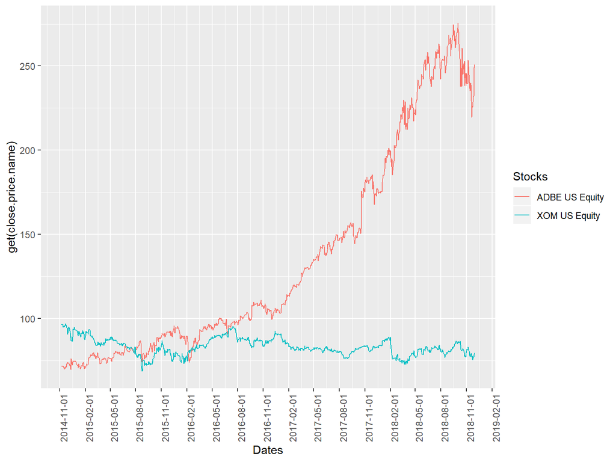

# Analysis

### Time Series Model

- ARIMA - one of the most widely used Timeseries Model
- Compare Model with Different Training Time Period

|  | RMSE | rate |
| --- | --- | --- |
| 1 | training_forty_month | 0.0118272911152242 |
| 2 | training_one_year | 0.00849755511717572 |
| 3 | training_half_year | 0.00909776979416156 |
| 4 | training_three_month | 0.0115058010730866 |
| 5 | test_forty_month | 0.0130198925758216 |
| 6 | test_one_year | 0.0130232760274093 |
| 7 | test_half_year | 0.0130112363512679 |
| 8 | test_three_month | 0.013011326963331 |

# Analysis

### Time Series Model

- Display the plot

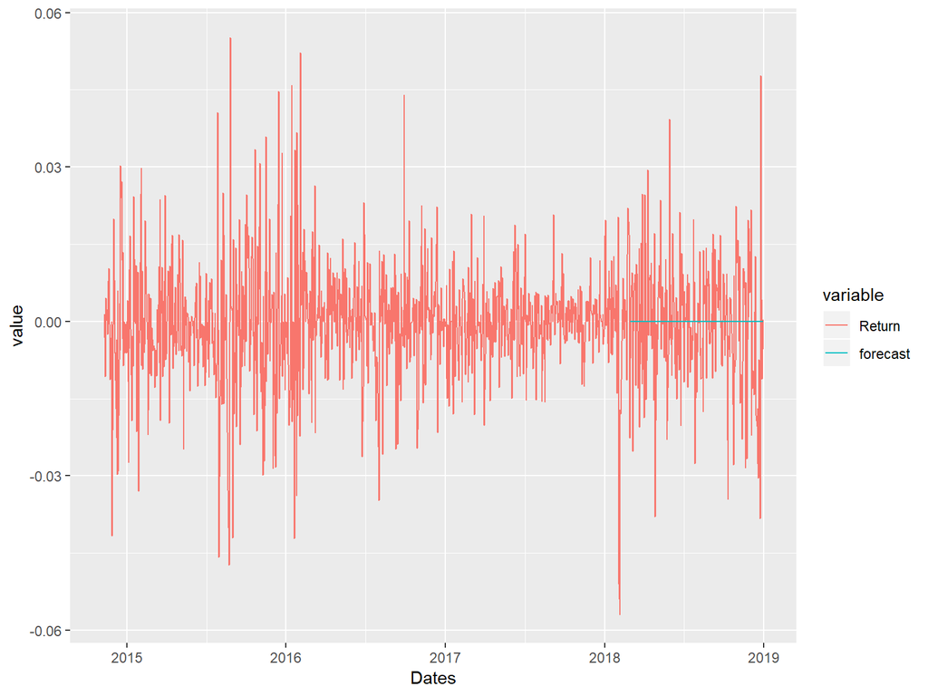

arima_forecast_forty_month_train

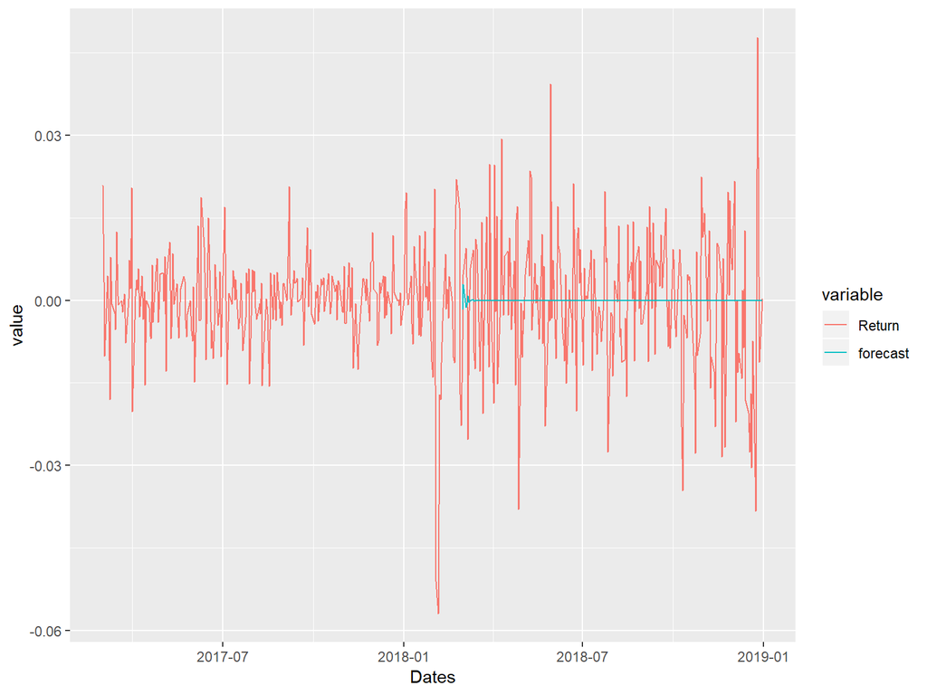

arima_forecast_one_year_train

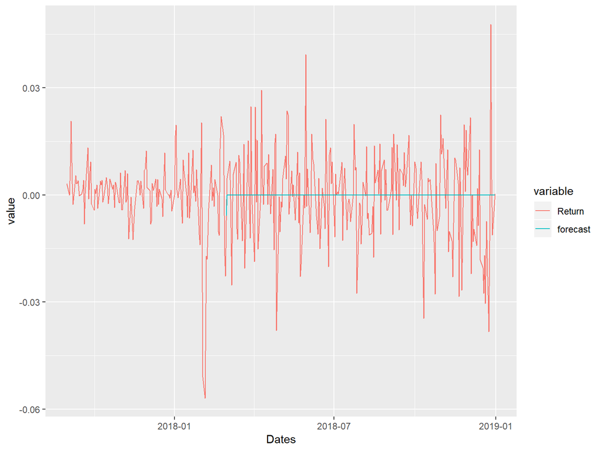

arima_forecast_half_year_train

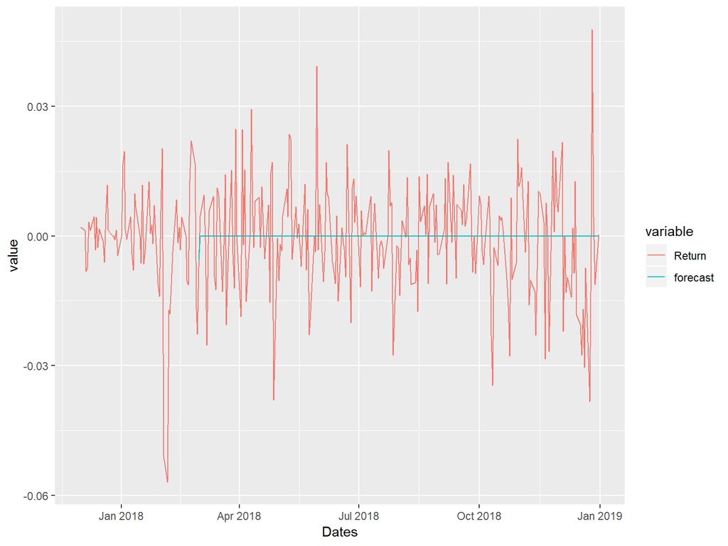

arima_forecast_three_month_train

# Analysis

### Support Vector Machine - Feature Selection

- Probability of Success: The number of months which the average monthly return of the first group of 50 months greater than the benchmark divided by total number of months.
- Wilcoxon Rank Sum Test: Test mean difference of monthly return of Group 1 and Group 5.
- Coefficients of Linear Model: We fitted 17 financial ratios as variables and returns as response variables into a linear model to see the sign of the coefficient.

| Financial Ratios | Probability of Success | Success | P-Values | Significant | Coefficients | Linear | Factor |
| --- | --- | --- | --- | --- | --- | --- | --- |
| PE_RATIO | 0.530612 | Yes | 0 | Yes | 0.029355 | Positive | PE_RATIO |
| PX_TO_BOOK_RATIO | 0.510204 | Yes | 0 | Yes | -0.026169 | Negative | PX_TO_BOOK_RATIO |
| PX_TO_SALES_RATIO | 0.469388 | No | 0 | Yes | -0.027117 | Negative | PX_TO_SALES_RATIO |
| PX_TO_FREE_CASH_FLOW | 0.510204 | Yes | 0 | Yes | -0.008565 | Negative | PX_TO_FREE_CASH_FLOW |
| EQY_DPS | 0.510204 | Yes | 0 | Yes | -0.007951 | Negative | EQY_DPS |
| RETURN_COM_EQY | 0.530612 | Yes | 0 | Yes | 0.028245 | Positive | RETURN_COM_EQY |
| RETURN_ON_ASSET | 0.469388 | No | 0 | Yes | -0.011326 | Negative | RETURN_ON_ASSET |
| SALES_GROWTH | 0.510204 | Yes | 0 | Yes | -0.011258 | Negative | SALES_GROWTH |
| EBITDA_GROWTH | 0.510204 | Yes | 0 | Yes | 0.016467 | Positive | EBITDA_GROWTH |
| EBITDA | 0.591837 | Yes | 0 | Yes | 0.035072 | Positive | EBITDA |

[output cut: 7 more lines]

# Analysis

### Support Vector Machine - Feature Selection

- Three different factor groups

|  | Factors Satisfies Two of Three Criteria |
| --- | --- |
| 1 | PE_RATIO |
| 2 | PX_TO_BOOK_RATIO |
| 3 | PX_TO_FREE_CASH_FLOW |
| 4 | EQY_DPS |
| 5 | RETURN_COM_EQY |
| 6 | SALES_GROWTH |
| 7 | EBITDA_GROWTH |
| 8 | EBITDA |
| 9 | RETURN_ON_INV_CAPITAL |
| 10 | TURNOVER |

[output cut: 4 more lines]

|  | Factors Satisfies Two of Three Criteria (Positive Coefficient) |
| --- | --- |
| 1 | PE_RATIO |
| 2 | RETURN_COM_EQY |
| 3 | EBITDA_GROWTH |
| 4 | EBITDA |
| 5 | PROF_MARGIN |
| 6 | ASSET_TURNOVER |
| 7 | NET_FIX_ASSET_TURN |
| 8 | INVENT_TURN |

|  | Factors Satisfies All Three Criteria |
| --- | --- |
| 1 | PE_RATIO |
| 2 | RETURN_COM_EQY |
| 3 | EBITDA_GROWTH |
| 4 | EBITDA |

# Analysis

### Support Vector Machine

- SVM Model after filtering on the 14-variable dataset
- SVM Model after filtering on the 8-variable dataset
- SVM Model after filtering on the 4-variable dataset

Display the accuracy results of three variable selected dataset.

|  | ME | RMSE | MAE |
| --- | --- | --- | --- |
| accuracy of 14 variables | -0.001558 | 0.015791 | 0.011576 |
| accuracy of 8 variables | -0.00311 | 0.017253 | 0.013389 |
| accuracy of 4 variables | -0.004628 | 0.016288 | 0.012441 |

# Analysis

### Support Vector Machine

- Compare Model with Different Training Time Period

  |  | ME | RMSE |
  | --- | --- | --- |
  | svm.model.info.fourty.month | -0.0012905406050206 | 0.0138309489614538 |
  | svm.model.info.one.year | -0.00226851569563138 | 0.0134069766131556 |
  | svm.model.info.half.year | 0.000689014646890458 | 0.0131470063679239 |
  | svm.model.info.three.month | 0.00647572499144052 | 0.0144067918886371 |

# Analysis

### Support Vector Machine

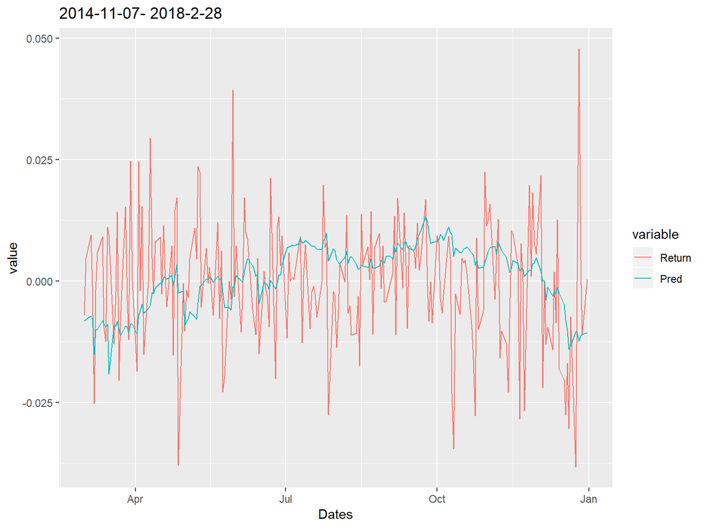

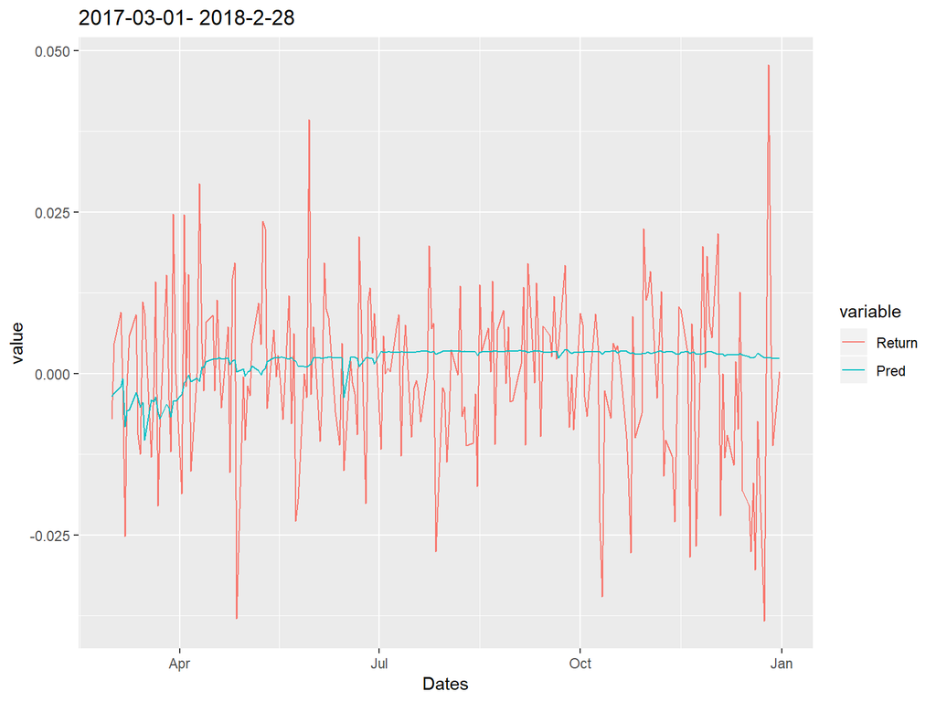

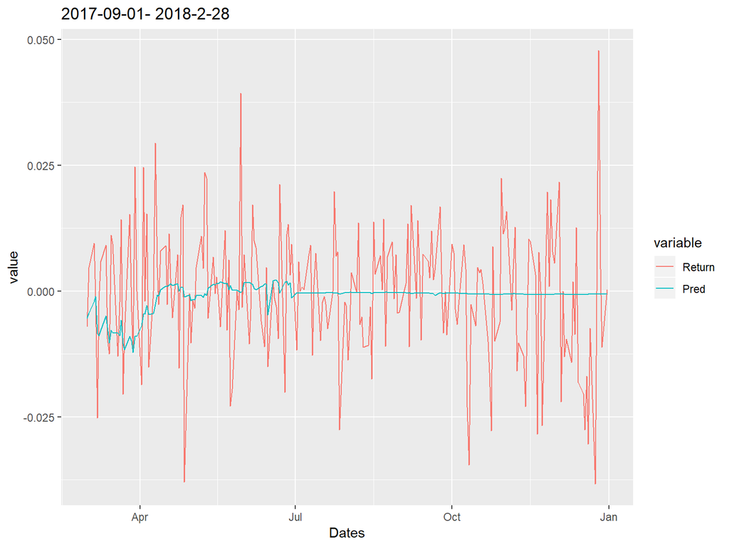

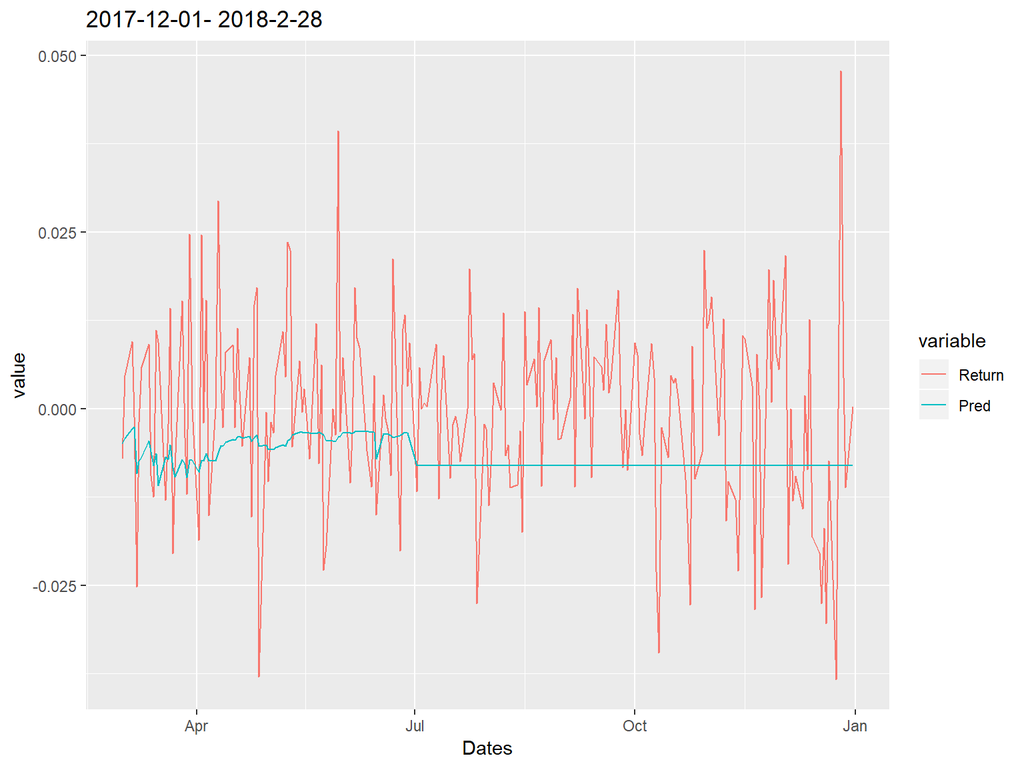

# Results

|  | RMSE | rate |
| --- | --- | --- |
| 1 | training_forty_month | 0.0118272911152242 |
| 2 | training_one_year | 0.00849755511717572 |
| 3 | training_half_year | 0.00909776979416156 |
| 4 | training_three_month | 0.0115058010730866 |
| 5 | test_forty_month | 0.0130198925758216 |
| 6 | test_one_year | 0.0130232760274093 |
| 7 | test_half_year | 0.0130112363512679 |
| 8 | test_three_month | 0.013011326963331 |

# Limitation

- Dataset is not large enough in terms of the variety of stocks and industry covered, as well as time period for the historical data.
- Consider correlation between financial ratios

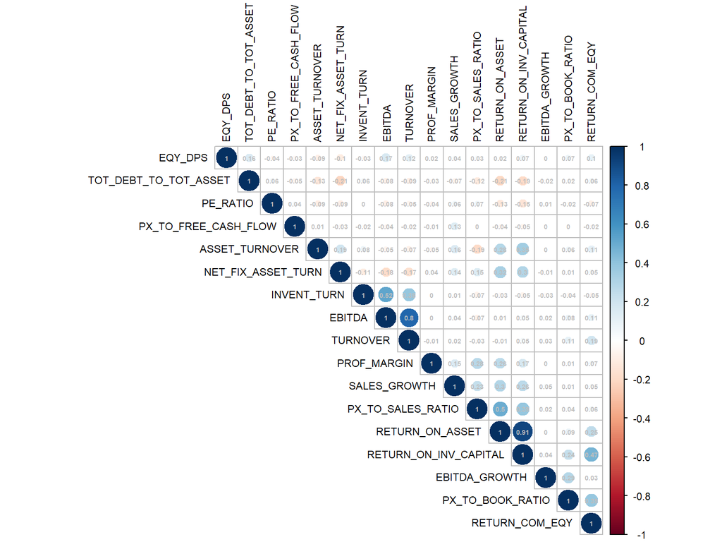

# Dashboard

Next, we will do a demonstration of the application we built for the project by using R shiny